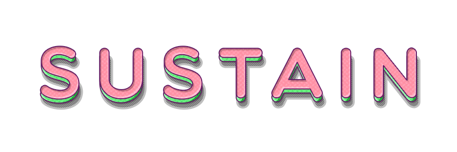

Sustain - Logo

## Table of Contents

- Installation
- Quick start
- Features
- Syntax highlighting
- Disqus
- Google Analytics
- About
- Contributing
- Changelog
- License

[figure not shown]

Sustain Screen

**[Sustain Live Demo](https://demo.nurlan.co/hugo-sustain/)**

## Installation

#### With `git`

From the root of your Hugo site, clone the theme into `themes/hugo-sustain` by running :

```
git clone https://github.com/nurlansu/hugo-sustain.git themes/hugo-sustain
```

#### Manual

1. [Download](https://github.com/nurlansu/hugo-sustain/archive/master.zip) zip archive.
2. Unarchive it.
3. Move `hugo-sustain` folder in `themes` folder of your blog

For more information read the official [setup guide](https://gohugo.io/overview/installing/) of Hugo.

## Quick start

```
  exampleSite
  ├── config.toml
  ├── content
  │   ├── projects.md
  │   │
  │   └── blog
  │       ├── creating-a-new-theme.md
  │       ├── go-is-for-lovers.md
  │       ├── hugo-is-for-lovers.md
  │       └── migrate-from-jekyll.md
  │
  ├── data
  │   └── projects.yml
  │
  └── static
```

Copy at least the `config.toml` in the root directory of your website. Overwrite the existing config file if necessary.

Hugo includes a development server, so you can view your changes as you go - very handy. Spin it up with the following command:

```bash
hugo serve
```

Now you can go to [localhost:1313](http://localhost:1313/) and the Sustain theme should be visible.

## Features

### Syntax highlighting

Use `highlight = true` in the front matter to include [`highlight.js`](https://highlightjs.org/) javascript and css files.

### Disqus

To use this feature, uncomment and fill out the `disqusShortname` parameter in config.toml`.

### Google Analytics

To add Google Analytics, simply sign up to [Google Analytics](https://www.google.com/analytics/) to obtain your Google Tracking ID, and add this tracking ID to the `googleAnalytics` parameter in `config.toml`.

## About

This is a port of the Jekyll theme [Sustain](https://github.com/biomadeira/sustain/) by [Fábio Madeira](https://github.com/biomadeira/). It supports most of the features of the original theme.

## Contributing

Pull requests, bug fixes, and new features are welcome!

1. Fork the repository
2. Create your feature branch (`git checkout -b my-new-feature`)
3. Commit your changes (`git commit -a -m 'Add some feature'`)
4. Push to the branch (`git push origin my-new-feature`)
5. Create new Pull Request on GitHub

## Changelog

> Version 1.0.1
- Added proper “Projects” page rendering
- Fixes, many fixes

> Version 1.0
- Initial release

## License

[figure not shown]

**MIT**